# R Basics

Savet Hong

March 6, 2018

## Purpose of Workshop

- Series
  - Provide overview of basic concepts of R, how to integrate this into current workflow, as well as, tips on debugging.
- Today’s session
  - Look and feel of R and RStudio (orientation for Noah’s course)
  - Essential concepts of R objects
  - There will be references to Excel and Stata.
  - This is not a course on statistics or data analysis.

## Resources

- Noah Lehman’s internal Data Science course
- Tomas Aragon’s book (https://bookdown.org/medepi/phds/)
- Hadly Wikham’s book (http://r4ds.had.co.nz/)
- MOOC (Coursera, EdX, Codecademy, DataCamp)

## What is R?

A free software that enables statistical computation, data analysis, and graphs. Built on these core functions are tools that allow users to enhance the features and integrate it with reports and interactive dashboarding on various platforms.

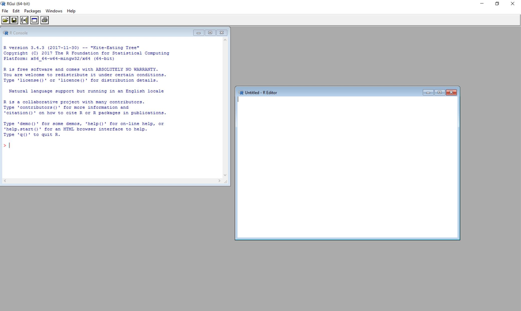

## What is RStudio?

A powerful integrated development environment (IDE) for R. It facilitate coding, compling, debugging, and deploying.

[figure not shown]

## Basic Calculation

What is 3*3?

- Excel
- Stata
- R

## How do you display “Coding Rocks!”?

- Excel
- Stata
- R

## R Objects

An object is a way of referencing data stored in the computer memory based on its data structure. Understanding the structure of data element is important as there are rules around what can and cannot be done with certain structure.

- Assign 3 to an object called “a”

  ```r
  a <- 3
  ```

- Call the object “a”

  ```r
  a
  ```

  ```
  ## [1] 3
  ```

- What is a*3?

## Is there an equivalent in Excel or Stata?

## What is the structure of a?

(What is the formatting of the information saved in the object?)

- Excel
- Stata

## Data Mode in R

```r
mode(3)
```

```
## [1] "numeric"
```

```r
mode(a)
```

```
## [1] "numeric"
```

- Note: calling and using a function requires “()”

  ```r
  str(3)
  ```

  ```
  ##  num 3
  ```

  ```r
  str(a)
  ```

  ```
  ##  num 3
  ```

## “Coding Rocks!”

- what is the mode?
- save it to an object

## Naming Conventions

1. R is case sensitive
2. Can be letters and numbers, BUT must start with a letter
3. accepts “_" and “.” in object name
4. names should be descriptive

## Multiple elements in a vector object

- Create the object

  ```r
  num <- rep(c("one","2","three"), times = 5)
  ```

- How many function was used to create “num”?
- What is the mode of “num”?
- How would you change the mode of “num” in
  - Excel?
  - Stata?
  - R?

## Change the mode of an object

- What is a factor?
- Convert “num” into a factor
- solution

  ```r
  factor(num)
  ```

  ```
  ##  [1] one   2     three one   2     three one   2     three one   2
  ## [12] three one   2     three
  ## Levels: 2 one three
  ```

  ```r
  num_fac <- factor(num)
  num_fac <- as.factor(num)
  ```

## Concepts covered

1. Overview of R and RStudio
2. Data objects (essentials…more to be covered)
3. Transform data object
4. Using built-in functions

## Exercises

- Create object containing a single value
- Create a numerical vector
- Perform arithmatic calculation using these two objects
  - What do you observe?
- Create an 2x5 matrix object
- Perform various arithmatic calculations using different combination of the three objects
  - What do you observe?
- Create a factor vector
- Change the value of one of the level
  - What happened?
  - How did you achieve this?